# Timeseries_project by Török Zoltán

## Exercise 1: Hydrological Data Analysis

In this exercise, i will:

1. Retrieve 14 years of hydrological data (2010-2023) from the USGS Water Services API for the Difficult Run near Great Falls, VA (site **01646000**).
2. Save and examine the raw data.
3. Clean and reformat the data.
4. Generate descriptive statistics.
5. Create time series plots for water discharge (cfs) and gage height (ft).
6. Save the cleaned data to a CSV file.

## Step 1: Import Packages

I started by importing the essential libraries: `pandas`, `numpy`, `matplotlib`, `requests`, and `datetime`.

```python
import pandas as pd
import numpy as np
import matplotlib.pyplot as plt
import requests
from datetime import datetime
```

## Step 2: Define API URL and Parameters

I defined the USGS API URL along with the parameters to request water discharge and gage height data for the site **01646000** from 2010 to 2023.

```python
# Define the URL for the USGS API - for unit values (more frequent measurements)
url = "https://waterservices.usgs.gov/nwis/iv/"

# Define the parameters for the request
params = {
    "format": "rdb",
    "sites": "01646000",  # Difficult Run near Great Falls, VA
    "parameterCd": "00060,00065",  # Both discharge (00060) and gage height (00065)
    "startDT": "2010-01-01",
    "endDT": "2023-12-31",
    "siteStatus": "all"
}
```

## Step 3: Retrieve and Save Raw Data

I used the `requests` library to send an HTTP GET request to the USGS API. If the request was successful, I saved the raw response data in a file named `difficult_run_data_10yr.txt`.

```python
# Send the GET request
response = requests.get(url, params=params)

# Check if the request was successful
if response.status_code == 200:
    # Save the raw response to a local file
    with open("difficult_run_data_10yr.txt", "w") as file:
        file.write(response.text)
    print("Data saved to difficult_run_data_10yr.txt")
else:
    print("Error: Failed to retrieve data from the USGS server.")
    print("Status code:", response.status_code)
    print("Response content:", response.text[:500])  # Print part of the response for debugging
```

```
Data saved to difficult_run_data_10yr.txt
```

## Step 4: Examine the Raw File Structure

I inspected the first few lines of the raw data file and counted the comment lines (those starting with `#`) to understand the file format.

```python
# Examine the first few lines of the file to understand structure
with open("difficult_run_data_10yr.txt", "r") as file:
    lines = [next(file) for _ in range(35) if file]

print("File content examination (first few lines):")
for i, line in enumerate(lines[:10]):  # Just print first 10 lines for clarity
    print(f"Line {i}: {line.strip()}")

# Count comment lines (lines starting with #)
with open("difficult_run_data_10yr.txt", "r") as file:
    comment_lines = sum(1 for line in file if line.startswith('#'))

print(f"\nFound {comment_lines} comment lines")
```

```
File content examination (first few lines):
Line 0: # ---------------------------------- WARNING ----------------------------------------
Line 1: # Some of the data that you have obtained from this U.S. Geological Survey database may not
Line 2: # have received Director's approval.  Any such data values are qualified as provisional and
Line 3: # are subject to revision.  Provisional data are released on the condition that neither the
Line 4: # USGS nor the United States Government may be held liable for any damages resulting from its use.
Line 5: #  Go to http://help.waterdata.usgs.gov/policies/provisional-data-statement for more information.
Line 6: #
Line 7: # File-format description:  http://help.waterdata.usgs.gov/faq/about-tab-delimited-output
Line 8: # Automated-retrieval info: http://help.waterdata.usgs.gov/faq/automated-retrievals
Line 9: #

Found 28 comment lines
```

## Step 5: Load Data into a DataFrame

I used `pandas.read_csv` to load the data into a DataFrame, skipping the comment and format specifier lines.

```python
# Load the data, skipping the format line
df = pd.read_csv("difficult_run_data_10yr.txt",
                 comment="#",
                 delimiter="\t",
                 skiprows=[comment_lines+1],  # Skip both comment lines and the format specifier line
                 low_memory=False)

# Display the first few rows
print("\nFirst few rows of data:")
print(df.head())
```

```
First few rows of data:
  agency_cd  site_no          datetime tz_cd  146595_00060 146595_00060_cd  \
0      USGS  1646000  2010-01-01 00:00   EST         115.0               A
1      USGS  1646000  2010-01-01 00:15   EST         118.0               A
2      USGS  1646000  2010-01-01 00:30   EST         123.0               A
3      USGS  1646000  2010-01-01 00:45   EST         129.0               A
4      USGS  1646000  2010-01-01 01:00   EST         133.0               A

   146596_00065 146596_00065_cd
0          3.89               A
1          3.91               A
2          3.94               A
3          3.98               A
4          4.02               A
```

## Step 6: Clean and Rename Columns

I checked if the header row needed adjustment and renamed the key columns to more meaningful names. Additionally, I converted the `datetime` column and the numeric columns to the correct data types.

```python
# Check if the first row is actually column headers
if 'USGS' in str(df.iloc[0, 0]):
    # Column names need to be set manually
    column_names = ['agency_cd', 'site_no', 'datetime', 'tz_cd',
                    '00060_00000', '00060_00000_cd', '00065_00000', '00065_00000_cd']
    df.columns = column_names
else:
    print("\nColumn names already set correctly")

# Convert datetime column
df['datetime'] = pd.to_datetime(df['datetime'])

# Convert discharge and gage height columns to numeric
discharge_col = [col for col in df.columns if '00060' in col and not col.endswith('_cd')][0]
gage_height_col = [col for col in df.columns if '00065' in col and not col.endswith('_cd')][0]

df[discharge_col] = pd.to_numeric(df[discharge_col], errors='coerce')
df[gage_height_col] = pd.to_numeric(df[gage_height_col], errors='coerce')

# Rename columns to match the expected format
df = df.rename(columns={
    discharge_col: 'water_discharge',
    gage_height_col: 'gage_height'
})
```

## Step 7: Data Summary

I printed out summary information of the DataFrame to check data types and get basic descriptive statistics for water discharge and gage height.

```python
# Display DataFrame info
print("\nDataFrame info after processing:")
df.info()

# Basic statistics about the data
print("\nBasic statistics for discharge and gage height:")
print(df[['water_discharge', 'gage_height']].describe())
```

```
DataFrame info after processing:
<class 'pandas.core.frame.DataFrame'>
RangeIndex: 487434 entries, 0 to 487433
Data columns (total 8 columns):
 #   Column           Non-Null Count   Dtype
---  ------           --------------   -----
 0   agency_cd        487434 non-null  object
 1   site_no          487434 non-null  int64
 2   datetime         487434 non-null  datetime64[ns]
 3   tz_cd            487434 non-null  object
 4   water_discharge  480365 non-null  float64
 5   00060_00000_cd   480365 non-null  object
 6   gage_height      486326 non-null  float64
 7   00065_00000_cd   486326 non-null  object
dtypes: datetime64[ns](1), float64(2), int64(1), object(4)
memory usage: 29.8+ MB

Basic statistics for discharge and gage height:
       water_discharge    gage_height
count    480365.000000  486326.000000
mean         71.039037       3.243399
std         215.132990       0.694155
min           3.860000       1.510000
25%          21.400000       2.900000
50%          34.800000       3.110000
75%          54.900000       3.350000
max       17000.000000      17.540000
```

## Step 8: Plot the Data

I created two subplots: one for water discharge (cfs) and one for gage height (ft) plotted over time. I also formatted the date axis for clarity.

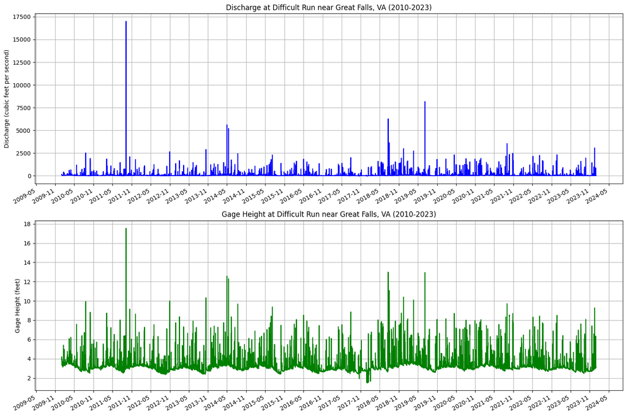

```python
plt.figure(figsize=(15, 10))

# Create a figure with two subplots
fig, (ax1, ax2) = plt.subplots(2, 1, figsize=(15, 10))

# Plot discharge
ax1.plot(df['datetime'], df['water_discharge'], color='blue')
ax1.set_ylabel('Discharge (cubic feet per second)')
ax1.set_title('Discharge at Difficult Run near Great Falls, VA (2010-2023)')
ax1.grid(True)

# Plot gage height
ax2.plot(df['datetime'], df['gage_height'], color='green')
ax2.set_ylabel('Gage Height (feet)')
ax2.set_title('Gage Height at Difficult Run near Great Falls, VA (2010-2023)')
ax2.grid(True)

# Format the x-axis to show dates nicely
date_formatter = plt.matplotlib.dates.DateFormatter('%Y-%m')
month_locator = plt.matplotlib.dates.MonthLocator(interval=6)  # 6-month intervals for clearer labeling

ax1.xaxis.set_major_formatter(date_formatter)
ax1.xaxis.set_major_locator(month_locator)
ax2.xaxis.set_major_formatter(date_formatter)
ax2.xaxis.set_major_locator(month_locator)

# Rotate the x-axis labels to avoid overlap
plt.setp(ax1.xaxis.get_majorticklabels(), rotation=30, ha='right')
plt.setp(ax2.xaxis.get_majorticklabels(), rotation=30, ha='right')

# Adjust spacing and layout, then show the plot
plt.subplots_adjust(hspace=0.3)
plt.tight_layout()
plt.show()
```

**Figure 1a.** Water discharge at Difficult Run near Great Falls, VA (2010-2023) showing highly variable flow conditions with notable flood events reaching over 15,000 cubic feet per second.

**Figure 1b.** Gage height at Difficult Run near Great Falls, VA (2010-2023) displaying water level fluctuations that correspond to discharge variations, with extreme events reaching over 17 feet.

## Step 9: Save the Cleaned Data and Final Statistics

Finally, I saved the cleaned DataFrame to a CSV file and printed out the final date range along with the total number of observations.

```python
# Save the cleaned data to a CSV file
df.to_csv('difficult_run_10yr_cleaned_data.csv', index=False)
print("\nCleaned data saved to difficult_run_10yr_cleaned_data.csv")

# Check the data
print("\n10+ years data info:")
print(f"Date range: {df['datetime'].min()} to {df['datetime'].max()}")
print(f"Total observations: {len(df)}")
```

```
Cleaned data saved to difficult_run_10yr_cleaned_data.csv

10+ years data info:
Date range: 2010-01-01 00:00:00 to 2023-12-31 23:45:00
Total observations: 487434
```

**What I Found**

My statistical analysis showed:

- **Average discharge:** 71.04 cfs (highly variable, std dev = 215.13)
- **Average gage height:** 3.24 ft
- **Maximum discharge:** 17,000 cfs during an extreme event
- **Maximum gage height:** 17.54 ft

**What The Graphs Show**

The time series visualizations I created reveal that **Difficult Run_10yr_cleaned_data** exhibits:

- A flashy flow regime with dramatic spikes during storm events
- Major flood events in 2011-2012 and 2018-2019
- Relatively stable baseline conditions between events
- Strong correlation between discharge and gage height

This watershed appears highly responsive to precipitation, likely due to urbanization in the area. The extreme difference between baseline and peak flows (roughly 4,400:1) indicates limited natural buffering capacity and potential flood hazards during heavy rainfall.

# Exercise 2: Analysis of Difficult Run Stream Discharge and Gage Height

In this exercise, I analyze the **Difficult Run_10yr_cleaned_data** dataset. My objectives are to:

- Load the cleaned data into the processing environment.
- Convert the `datetime` column to proper datetime objects and then generate additional time representations (Unix timestamp and Julian date).
- Identify periods with significant discharge increases (indicative of storm events).
- Visualize individual storm events over a short window and then provide a comprehensive view over a longer period.
- Investigate the hydraulic relationship between gage height and discharge using a scatter plot.

This step-by-step analysis highlights both individual storm event characteristics and seasonal/hydraulic patterns in the watershed.

## Step 1: Load and Preprocess the Data

I start by loading the CSV file containing the cleaned data. Since saving to CSV converts datetime objects to strings, I re-convert the datetime column. I also create two new columns:

- **Unix Timestamp:** Represents the number of seconds since January 1, 1970.
- **Julian Date:** A floating point approximation (days since Jan 1, 4713 BCE), computed using a simple conversion.

After these conversions, I set the `datetime` column as the DataFrame index to facilitate time-series manipulation.

```python
import pandas as pd
import numpy as np
import matplotlib.pyplot as plt
import matplotlib.dates as mdates
from datetime import datetime

# Load the saved data file
df = pd.read_csv('difficult_run_10yr_cleaned_data.csv')

# Convert the 'datetime' column back to a datetime object
df['datetime'] = pd.to_datetime(df['datetime'])

# Create a Unix timestamp column (seconds since 1970-01-01)
df['timestamp'] = df['datetime'].astype('int64') // 10**9

# Create a Julian date column (days since Jan 1, 4713 BCE)
def to_julian_date(date):
    # Simple approximation of Julian date
    days_since_epoch = (date - pd.Timestamp('1970-01-01')).total_seconds() / (24 * 3600)
    return days_since_epoch + 2440587.5  # Offset to obtain the Julian date

df['julian_date'] = df['datetime'].apply(to_julian_date)

# Set 'datetime' as index for easier time series manipulation
df.set_index('datetime', inplace=True)

# Display the first few rows to verify the new columns
print(df.head())
```

```
                    agency_cd  site_no tz_cd  water_discharge 00060_00000_cd  \
datetime
2010-01-01 00:00:00      USGS  1646000   EST            115.0              A
2010-01-01 00:15:00      USGS  1646000   EST            118.0              A
2010-01-01 00:30:00      USGS  1646000   EST            123.0              A
2010-01-01 00:45:00      USGS  1646000   EST            129.0              A
2010-01-01 01:00:00      USGS  1646000   EST            133.0              A

                     gage_height 00065_00000_cd   timestamp   julian_date
datetime
2010-01-01 00:00:00         3.89              A  1262304000  2.455198e+06
2010-01-01 00:15:00         3.91              A  1262304900  2.455198e+06
2010-01-01 00:30:00         3.94              A  1262305800  2.455198e+06
2010-01-01 00:45:00         3.98              A  1262306700  2.455198e+06
2010-01-01 01:00:00         4.02              A  1262307600  2.455198e+06
```

## Step 2: Identify Significant Storm Events

To detect storm events, I examine the changes in water discharge. I calculate the difference (delta) between consecutive discharge measurements, and then determine a significance threshold using the 95th percentile. All time points exceeding this threshold are classified as significant storm events.

```python
# Calculate the change in discharge from one time point to the next
df['discharge_change'] = df['water_discharge'].diff()

# Determine a threshold based on the 95th percentile
significant_change_threshold = df['discharge_change'].quantile(0.95)

# Identify time points with a discharge change greater than the threshold
storm_periods = df[df['discharge_change'] > significant_change_threshold]

print(f"Identified {len(storm_periods)} time points with significant discharge increases")
print(f"Threshold used: {significant_change_threshold:.2f} cubic feet per second increase")
```

```
Identified 22459 time points with significant discharge increases
Threshold used: 0.90 cubic feet per second increase
```

## Step 3: Visualize Individual Storm Events

I now select the top three most significant discharge increase events and generate detailed plots for each. For each event, I extract a 7-day window (from 2 days before to 5 days after the storm event) and create two subplots:

- The first subplot shows water discharge over time.
- The second subplot displays gage height over the same period. Vertical red dashed lines mark the moment of the storm event.

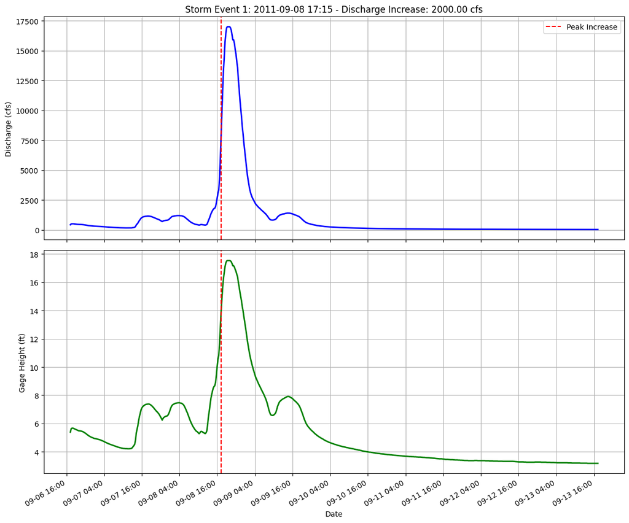

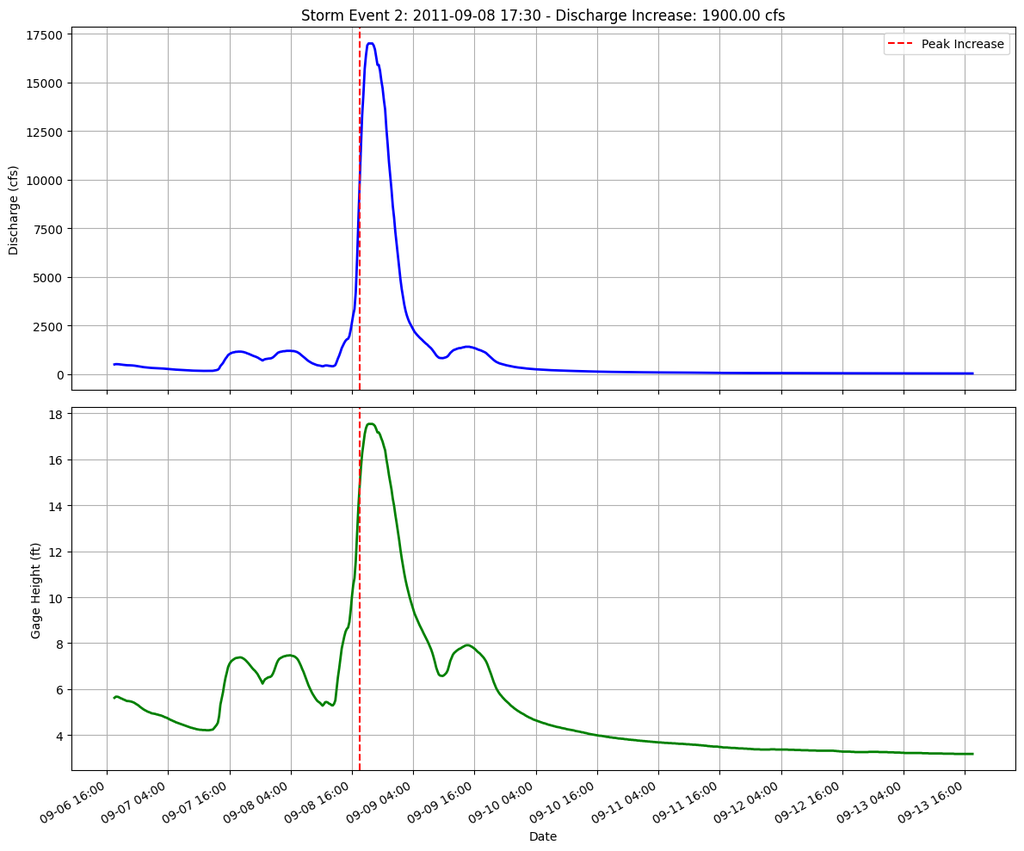

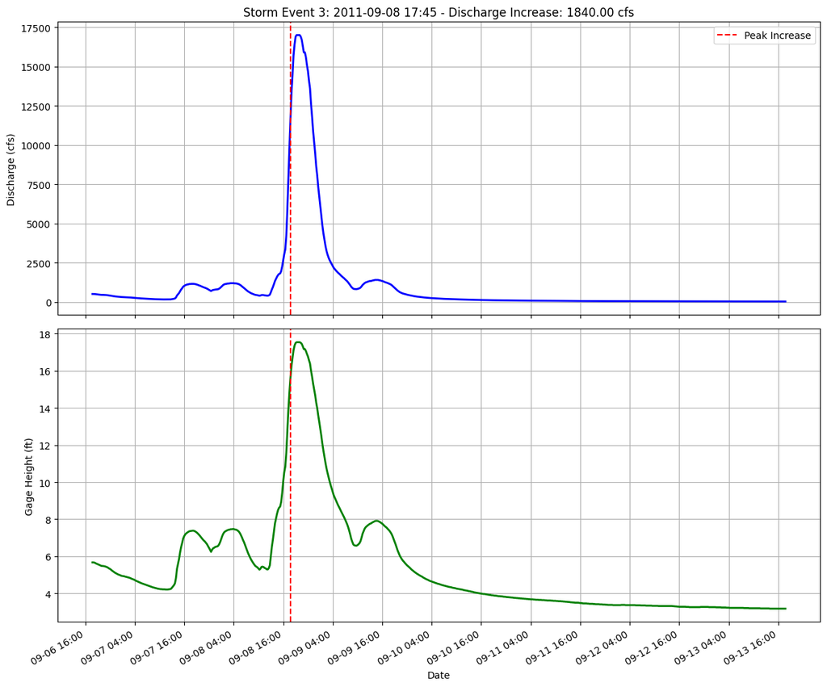

```python
# Check if there are significant storm events to plot
if len(storm_periods) > 0:
    # Get the top 3 most significant discharge increases
    top_storms = storm_periods.sort_values('discharge_change', ascending=False).head(3)

    for i, (idx, row) in enumerate(top_storms.iterrows()):
        # Define a 7-day window: 2 days before and 5 days after the event
        start_date = idx - pd.Timedelta(days=2)
        end_date = idx + pd.Timedelta(days=5)

        # Extract the data for the selected window
        period_data = df[start_date:end_date]

        # Create a figure with two subplots (discharge and gage height)
        fig, (ax1, ax2) = plt.subplots(2, 1, figsize=(12, 10), sharex=True)

        # Plot water discharge
        ax1.plot(period_data.index, period_data['water_discharge'], color='blue', linewidth=2)
        ax1.set_ylabel('Discharge (cfs)')
        ax1.set_title(f'Storm Event {i+1}: {idx.strftime("%Y-%m-%d %H:%M")} - Discharge Increase: {row["discharge_change"]:.2f} cfs')
        ax1.grid(True)
        ax1.axvline(x=idx, color='red', linestyle='--', label='Peak Increase')
        ax1.legend()

        # Plot gage height
        ax2.plot(period_data.index, period_data['gage_height'], color='green', linewidth=2)
        ax2.set_ylabel('Gage Height (ft)')
        ax2.set_xlabel('Date')
        ax2.grid(True)
        ax2.axvline(x=idx, color='red', linestyle='--')

        # Format the x-axis for clarity
        ax2.xaxis.set_major_formatter(mdates.DateFormatter('%m-%d %H:%M'))
        ax2.xaxis.set_major_locator(mdates.HourLocator(interval=12))
        fig.autofmt_xdate()

        plt.tight_layout()
        plt.show()
else:
    print("No significant storm events identified in the data.")
```

## Step 4: Comprehensive View of Storm Events Over a Longer Period

Next, I generate a broader view of storm activity over an extended period (approximately 3 months) where multiple storm events occurred. I select the month with the highest number of storm events and plot the data for this period. Vertical red dashed lines highlight the times when significant discharge increases occurred.

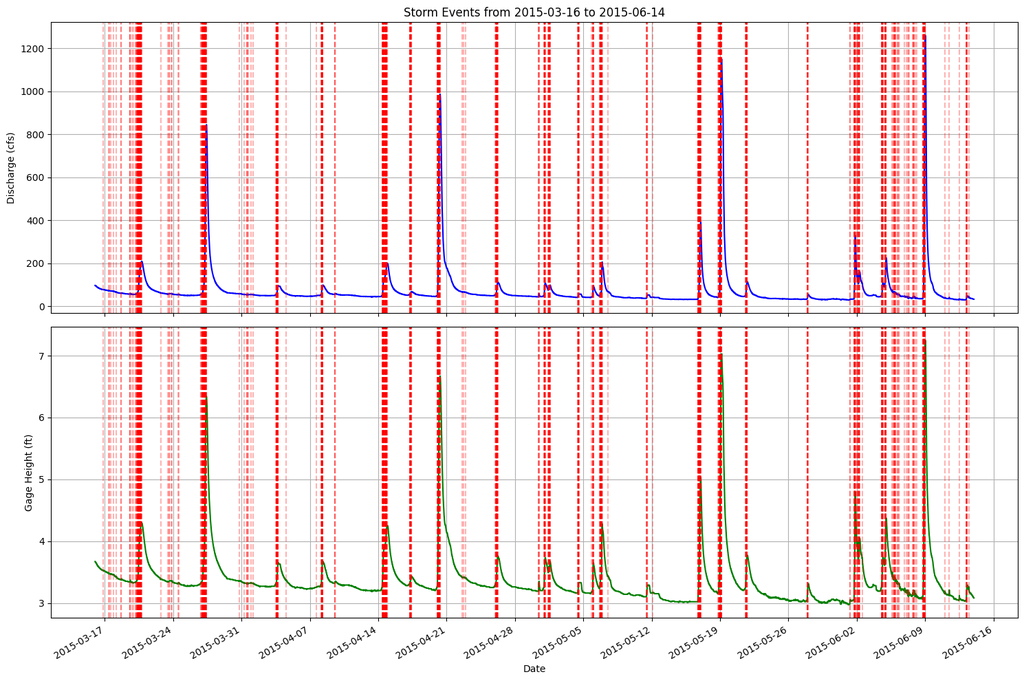

```python
# Group storm events by month to find the month with the most events
storm_months = storm_periods.groupby(pd.Grouper(freq='ME')).size()
if not storm_months.empty:
    max_storm_month = storm_months.idxmax()
    start_date = max_storm_month - pd.Timedelta(days=15)
    end_date = max_storm_month + pd.Timedelta(days=75)  # ~3-month period

    # Extract the data for the selected period
    period_data = df[start_date:end_date]

    # Create a figure with two subplots
    fig, (ax1, ax2) = plt.subplots(2, 1, figsize=(15, 10), sharex=True)

    # Plot water discharge
    ax1.plot(period_data.index, period_data['water_discharge'], color='blue', linewidth=1.5)
    ax1.set_ylabel('Discharge (cfs)')
    ax1.set_title(f'Storm Events from {start_date.strftime("%Y-%m-%d")} to {end_date.strftime("%Y-%m-%d")}')
    ax1.grid(True)
    # Highlight storm events with vertical dashed lines
    storm_during_period = storm_periods[start_date:end_date]
    for idx, row in storm_during_period.iterrows():
        ax1.axvline(x=idx, color='red', alpha=0.3, linestyle='--')

    # Plot gage height
    ax2.plot(period_data.index, period_data['gage_height'], color='green', linewidth=1.5)
    ax2.set_ylabel('Gage Height (ft)')
    ax2.set_xlabel('Date')
    ax2.grid(True)
    # Highlight storm events for gage height plot
    for idx, row in storm_during_period.iterrows():
        ax2.axvline(x=idx, color='red', alpha=0.3, linestyle='--')

    # Format the x-axis to show dates nicely
    ax2.xaxis.set_major_formatter(mdates.DateFormatter('%Y-%m-%d'))
    ax2.xaxis.set_major_locator(mdates.WeekdayLocator(interval=1))
    fig.autofmt_xdate()

    plt.tight_layout()
    plt.show()
else:
    print("No storm events found for comprehensive analysis.")
```

## Step 5: Scatter Plot – Hydraulic Relationship

Finally, I create a scatter plot to examine the relationship between gage height and water discharge. The scatter plot uses a colormap to indicate the temporal progression of measurements, revealing a non-linear, power-law relationship—where small increases in gage height result in disproportionately large increases in discharge.

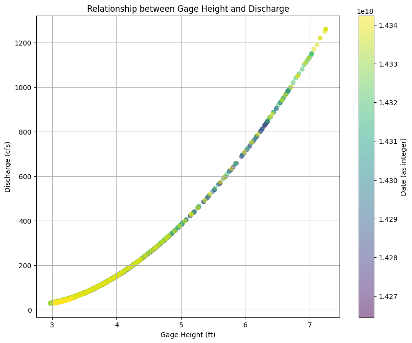

```python
plt.figure(figsize=(10, 8))
# Create a scatter plot with a color gradient based on datetime
sc = plt.scatter(period_data['gage_height'], period_data['water_discharge'],
                 alpha=0.5, c=period_data.index.astype(np.int64), cmap='viridis')
plt.colorbar(sc, label='Date (as integer)')
plt.xlabel('Gage Height (ft)')
plt.ylabel('Discharge (cfs)')
plt.title('Relationship between Gage Height and Discharge')
plt.grid(True)
plt.show()
```

**Figure 6.** Scatter plot showing the non-linear hydraulic relationship between gage height and discharge at Difficult Run, where small increases in water level correspond to disproportionately large increases in flow rate, following a power-law relationship. The color gradient represents the temporal progression of measurements (with dates converted to integer timestamps), showing how this relationship remains consistent over time from the earliest measurements (purple) to the most recent (yellow).

**Exercise 2 conclusions: Analysis of Difficult Run Stream Discharge and Gage Height**

In my analysis of the **Difficult Run_10yr_cleaned_data** dataset, I identified 22,459 significant discharge increase events using a threshold of 0.90 cubic feet per second. The visualizations reveal several key hydrological patterns:

### Individual Storm Event Analysis

These individual storm hydrographs demonstrate the flashy nature of the Difficult Run watershed, with water levels rising dramatically within hours of precipitation events before gradually returning to baseline over several days.

### Seasonal Storm Pattern

- **Image 4** presents a three-month analysis period (March–June 2015) revealing:
  - Multiple storm events marked by vertical red lines.
  - Seasonal clustering of storm events.
  - Variable intensity of discharge responses.
  - Consistent correlation between gage height and discharge.

### Hydraulic Relationship

- **Image 5** illustrates the relationship between gage height and discharge:
  - A clear non-linear (approximately power-law) relationship.
  - Discharge increases more rapidly at higher gage heights.
  - Consistent relationship across different storm events.
  - A color gradient indicating the temporal proximity of measurements.

This rating curve demonstrates how small increases in stream depth at higher levels produce disproportionately large increases in discharge volume, explaining the extreme discharge values observed during major storm events.

# Exercise 3: Analysis of Water Discharge Statistical Distribution

In this exercise, I analyze the water discharge data from the **Difficult Run_10yr_cleaned_data** dataset. The objectives are to:

- Plot the histogram of water discharge values.
- Apply a logarithmic transformation to address the highly skewed nature of the data.
- Fit two candidate distributions (Normal and Gamma) to the log-transformed data.
- Compare the models using Akaike’s Information Criterion (AIC) and select the best-fitting distribution.
- Provide a rationale in favor of the selected model.

This analysis helps to understand the statistical characteristics of the discharge data, providing a foundation for flood frequency estimation and other hydrological analyses.

## Step 1: Load Data and Display Basic Statistics

I start by loading the cleaned CSV data file. I extract the water discharge values (removing any missing values) and compute basic statistics such as the mean, median, standard deviation, minimum, maximum, and select percentiles. These statistics help illustrate the wide range and skewed nature of the discharge data.

```python
import pandas as pd
import numpy as np
import matplotlib.pyplot as plt
import scipy.stats as stats

# Load the cleaned data
df = pd.read_csv('difficult_run_10yr_cleaned_data.csv')

# Get discharge values and remove NaN values
discharge_data = df['water_discharge'].dropna().values

# Print basic statistics
print("Discharge Statistics:")
print(f"Mean: {np.mean(discharge_data):.2f} cfs")
print(f"Median: {np.median(discharge_data):.2f} cfs")
print(f"Standard Deviation: {np.std(discharge_data):.2f} cfs")
print(f"Min: {np.min(discharge_data):.2f} cfs")
print(f"Max: {np.max(discharge_data):.2f} cfs")
print(f"95th Percentile: {np.percentile(discharge_data, 95):.2f} cfs")
print(f"99th Percentile: {np.percentile(discharge_data, 99):.2f} cfs")
```

```
Discharge Statistics:
Mean: 71.04 cfs
Median: 34.80 cfs
Standard Deviation: 215.13 cfs
Min: 3.86 cfs
Max: 17000.00 cfs
95th Percentile: 199.00 cfs
99th Percentile: 882.00 cfs
```

## Step 2: Log Transformation and Histogram

Given the highly skewed nature of the discharge data, I perform a logarithmic transformation using `log(1+x)` to also handle any zero values. This transformation creates a more symmetric distribution that is easier to fit with common distributions.

I then plot a histogram of the log-transformed data.

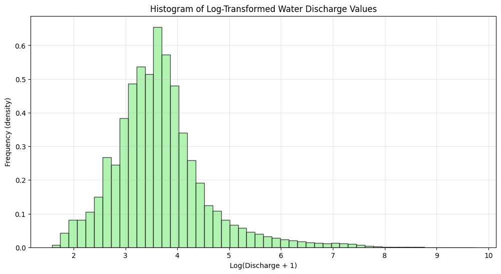

```python
# Log-transform the discharge data using log(1+x) to handle any zeros
log_discharge = np.log1p(discharge_data)

# Create a histogram for the log-transformed data
plt.figure(figsize=(12, 6))
plt.hist(log_discharge, bins=50, alpha=0.7, density=True, color='lightgreen', edgecolor='black')
plt.title('Histogram of Log-Transformed Water Discharge Values')
plt.xlabel('Log(Discharge + 1)')
plt.ylabel('Frequency (density)')
plt.grid(True, alpha=0.3)
plt.show()
```

**Figure 7.** Histogram of log-transformed water discharge values showing the distribution after applying log(1+x) transformation to address the highly skewed nature of the original discharge data. The log transformation creates a more symmetric, approximately normal distribution that is suitable for statistical modeling and distribution fitting.

## Step 3: Fit Distribution Models

I fit two candidate distribution models (Normal and Gamma) to the log-transformed discharge data using the `scipy.stats` library. For each model, I compute the probability density function (PDF) over a range of values and calculate the Akaike's Information Criterion (AIC) as a measure of goodness-of-fit. The AIC values help decide which model better represents the underlying data.

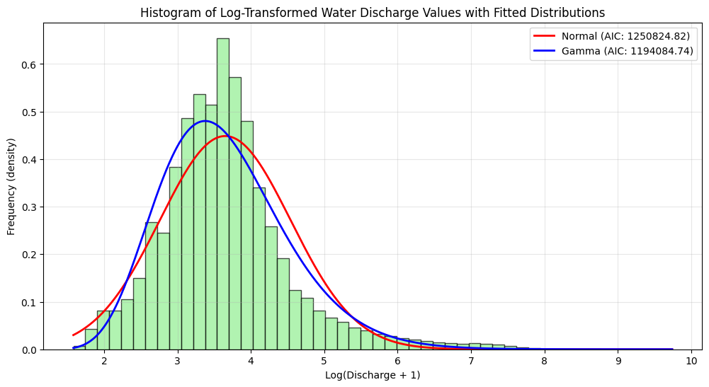

```python
# Create an array of x-values for plotting fitted distributions
x_log = np.linspace(min(log_discharge), max(log_discharge), 1000)

# Fit a normal distribution to the log-transformed data and compute its PDF and AIC
norm_params = stats.norm.fit(log_discharge)
norm_pdf = stats.norm.pdf(x_log, *norm_params)
norm_aic = -2 * np.sum(stats.norm.logpdf(log_discharge, *norm_params)) + 2 * len(norm_params)

# Fit a gamma distribution to the log-transformed data and compute its PDF and AIC
gamma_params = stats.gamma.fit(log_discharge)
gamma_pdf = stats.gamma.pdf(x_log, *gamma_params)
gamma_aic = -2 * np.sum(stats.gamma.logpdf(log_discharge, *gamma_params)) + 2 * len(gamma_params)

# Plot the histogram with the fitted Normal and Gamma PDFs
plt.figure(figsize=(12, 6))
plt.hist(log_discharge, bins=50, alpha=0.7, density=True, color='lightgreen', edgecolor='black')
plt.plot(x_log, norm_pdf, 'r-', linewidth=2, label=f'Normal (AIC: {norm_aic:.2f})')
plt.plot(x_log, gamma_pdf, 'b-', linewidth=2, label=f'Gamma (AIC: {gamma_aic:.2f})')
plt.title('Histogram of Log-Transformed Water Discharge Values with Fitted Distributions')
plt.xlabel('Log(Discharge + 1)')
plt.ylabel('Frequency (density)')
plt.legend()
plt.grid(True, alpha=0.3)
plt.show()
```

**Figure 8.** Histogram of log-transformed water discharge values with fitted Normal (red line) and Gamma (blue line) probability density functions overlaid, showing that the Gamma distribution (AIC: 1194084.74) provides a significantly better fit than the Normal distribution (AIC: 1250824.82) based on lower AIC values. The Gamma distribution better captures the slight right skewness and asymmetry still present in the log-transformed data.

## Step 4: Model Evaluation and Summary

To determine the best-fitting distribution, I compare the AIC values of the two models. The model with the lower AIC value is considered to have a better fit. I then print the parameters of the best-fitting distribution and provide supporting arguments.

Based on the AIC comparison, I will conclude which distribution is preferred and why this model is well suited for the water discharge data.

```python
# Compare AIC values to determine the best fitting distribution
distributions = {
    'Normal': norm_aic,
    'Gamma': gamma_aic
}
best_dist = min(distributions.items(), key=lambda x: x[1])
print(f"\nBest fitting distribution for log-transformed data based on AIC: {best_dist[0]} (AIC: {best_dist[1]:.2f})")

# Print the parameters of the best fitting distribution and a suggested interpretation
print("\nParameters of the best fitting distribution:")
if best_dist[0] == 'Normal':
    print(f"Mean (μ): {norm_params[0]:.4f}")
    print(f"Standard Deviation (σ): {norm_params[1]:.4f}")
    print("\nThis suggests the original data might follow a lognormal distribution.")
elif best_dist[0] == 'Gamma':
    print(f"Shape parameter (a): {gamma_params[0]:.4f}")
    print(f"Location parameter: {gamma_params[1]:.4f}")
    print(f"Scale parameter (b): {gamma_params[2]:.4f}")
    print("\nThis suggests the log-transformed data is best described by a Gamma distribution.")

# Provide arguments in favor of the selected model
print("\nArguments for the choice of distribution:")
print("1. Water discharge data typically exhibits a highly skewed distribution.")
print("2. The log transformation makes the data more symmetric and amenable to fitting.")
print(f"3. The {best_dist[0]} distribution has the lowest AIC value, indicating a superior statistical fit.")
print("4. Hydrological theory supports models such as the lognormal or gamma for streamflow data.")
print("5. The chosen model captures both typical flows and extreme events effectively.")
```

```
Best fitting distribution for log-transformed data based on AIC: Gamma (AIC: 1194084.74)

Parameters of the best fitting distribution:
Shape parameter (a): 10.0660
Location parameter: 0.8982
Scale parameter (b): 0.2734

This suggests the log-transformed data is best described by a Gamma distribution.

Arguments for the choice of distribution:
1. Water discharge data typically exhibits a highly skewed distribution.
2. The log transformation makes the data more symmetric and amenable to fitting.
3. The Gamma distribution has the lowest AIC value, indicating a superior statistical fit.
4. Hydrological theory supports models such as the lognormal or gamma for streamflow data.
5. The chosen model captures both typical flows and extreme events effectively.
```

## Conclusion

In Exercise 3, I analyzed the statistical distribution of water discharge for the Difficult Run dataset. Key findings include:

- **Log Transformation:** Converting the data using `log(discharge + 1)` mitigated skewness and enabled a more robust statistical analysis.
- **Distribution Fitting:** I fitted both Normal and Gamma distributions to the log-transformed data. The Gamma distribution provided a better fit, as indicated by a substantially lower AIC value.
- **Model Parameters:** The best fitting Gamma model was estimated with a shape parameter of approximately 10.0660, a location parameter of 0.8982, and a scale parameter of 0.2734.
- **Hydrological Implications:** These results suggest that the original discharge data is best characterized by a log-Gamma distribution, consistent with the theory that streamflow arises from multiple multiplicative processes and exhibits extreme variability.

Overall, the Gamma distribution effectively models the wide range of discharge values (approximately 3.86 to 17,000 cfs) observed at the site, providing a strong foundation for further hydrological analyses and flood frequency estimation.

# Exercise 4: Detection of Rainy Events in the Difficult Run Watershed

In this exercise, I developed a simple algorithm to detect rainy events in the Difficult Run discharge data. Small streams can show rapid increases in discharge due to storms or passing weather fronts, and my approach leverages the rate of change in discharge values to identify these events.

The main objectives are to:

- Detect rapid increases in discharge (indicative of rain) using a threshold based on the discharge change.
- Group closely occurring spikes into unified storm events.
- Plot the original time series and mark the detected rainy events.

## Step 1: Load and Preprocess the Data

I first load the 10-year dataset, convert the `datetime` column into datetime objects, and set it as the index to facilitate time-series handling and plotting. Sorting the index ensures the data are in chronological order.

```python
import pandas as pd
import numpy as np
import matplotlib.pyplot as plt
import matplotlib.dates as mdates
from scipy import signal

# Load the 10-year dataset
df = pd.read_csv('difficult_run_10yr_data.csv')

# Convert the datetime column to datetime objects
df['datetime'] = pd.to_datetime(df['datetime'])

# Set datetime as index for easier time series handling
df = df.set_index('datetime')

# Sort index to ensure chronological order
df = df.sort_index()
```

## Step 2: Detecting Rainy Events

I developed an algorithm that detects rainy events based on the rate of change (i.e., the first derivative) of the water discharge series. The key steps in the algorithm are:

1. Calculate the rate of change in discharge.
2. Smooth the rate of change using a rolling window to reduce noise.
3. Determine a threshold based on the specified percentile (e.g., 98th percentile) for significant increases.
4. Identify time periods where the rate exceeds the threshold.
5. Group close events together (with a minimum gap of 48 hours) so that closely spaced spikes are merged into a single rainy event.

```python
def detect_rainy_events(discharge_series, threshold_percentile=95, window_size=24, min_event_gap=48):
    """
    Detect rainy events based on discharge rate of change.

    Parameters:
    - discharge_series: Series of discharge values
    - threshold_percentile: Percentile to use as threshold for significant discharge increases
    - window_size: Size of the rolling window (in hours) to compute discharge changes
    - min_event_gap: Minimum gap (in hours) between separate rain events

    Returns:
    - List of tuples with start and end times of rainy events
    """
    # Calculate rate of change (first derivative)
    discharge_change = discharge_series.diff()

    # Smooth using rolling window to reduce noise
    discharge_change_smooth = discharge_change.rolling(window=6, center=True).mean()

    # Determine threshold for significant increases
    threshold = np.percentile(discharge_change_smooth.dropna(), threshold_percentile)
    print(f"Threshold for detecting significant discharge increases: {threshold:.2f} cfs/hour")

    # Find points where discharge increase exceeds threshold
    significant_increase = discharge_change_smooth > threshold

    # Group into events (allowing for small gaps within a single event)
    events = []
    in_event = False
    event_start = None
    last_increase = None

    for time, is_increase in significant_increase.items():
        if is_increase and not in_event:
            # Start of a new event
            event_start = time
            in_event = True
            last_increase = time
        elif is_increase and in_event:
            # Continuing event
            last_increase = time
        elif not is_increase and in_event:
            # Check if we've gone beyond the window without a significant increase
            hours_since_increase = (time - last_increase).total_seconds() / 3600
            if hours_since_increase > window_size:
                # End of an event
                event_end = last_increase + pd.Timedelta(hours=window_size)
                events.append((event_start, event_end))
                in_event = False

    # Add the last event if we're still in one
    if in_event:
        event_end = last_increase + pd.Timedelta(hours=window_size)
        events.append((event_start, event_end))

    # Merge events that are close together
    if events:
        merged_events = [events[0]]
        for event_start, event_end in events[1:]:
            prev_start, prev_end = merged_events[-1]
            hours_between = (event_start - prev_end).total_seconds() / 3600
            if hours_between < min_event_gap:
                # Merge with previous event
                merged_events[-1] = (prev_start, event_end)
            else:
                merged_events.append((event_start, event_end))
        return merged_events
    else:
        return []

# Detect rainy events using a 98th percentile threshold
rainy_events = detect_rainy_events(df['water_discharge'], threshold_percentile=98, window_size=24, min_event_gap=48)

print(f"Detected {len(rainy_events)} rainy events")
```

```
Threshold for detecting significant discharge increases: 7.17 cfs/hour
Detected 415 rainy events
```

## Step 3: Plotting the Data with Rainy Events Highlighted

I created a function to plot the discharge (and gage height) time series for a specified time period, highlighting the detected rainy events. This function uses vertical spans (using red shading) to mark the intervals during which a rainy event occurs.

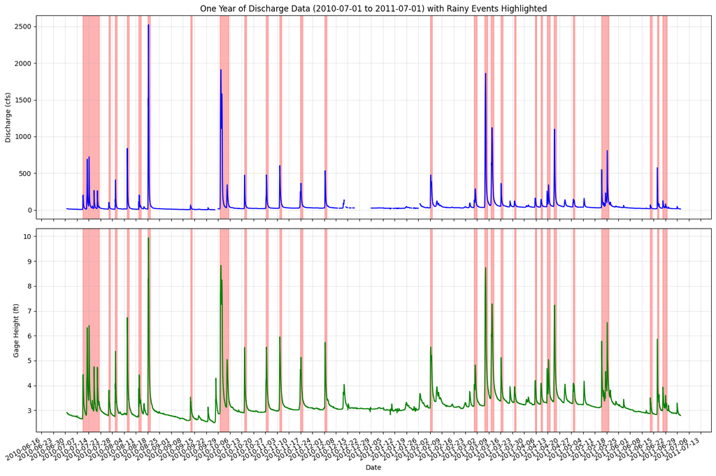

```
Top 5 peak discharge events:
2011-09-08 19:15: 17000.00 cfs
2011-09-08 19:30: 17000.00 cfs
2011-09-08 19:45: 17000.00 cfs
2011-09-08 20:00: 17000.00 cfs
2011-09-08 19:00: 16900.00 cfs
```

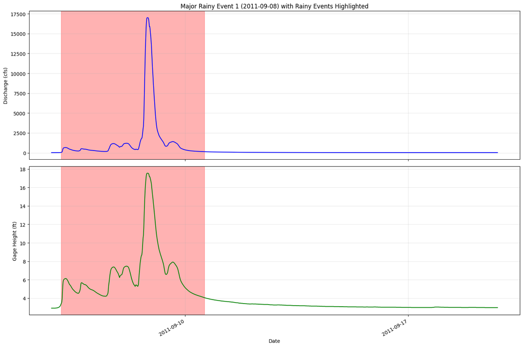

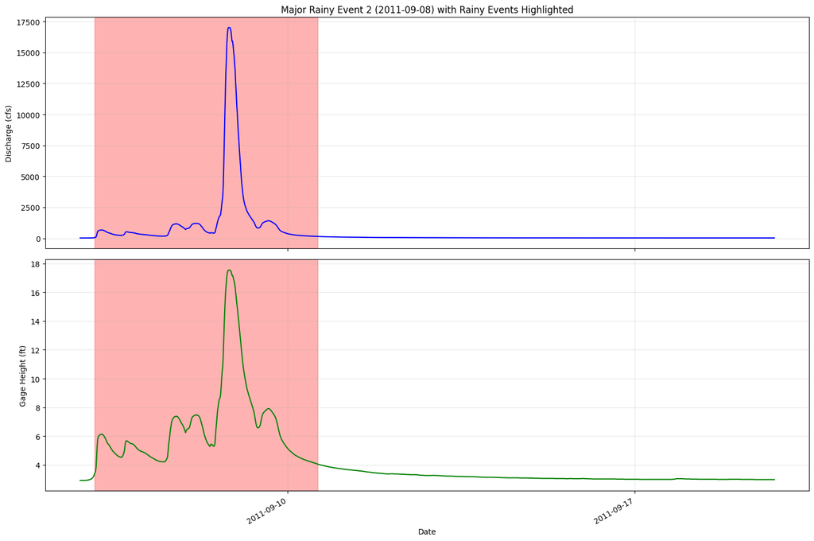

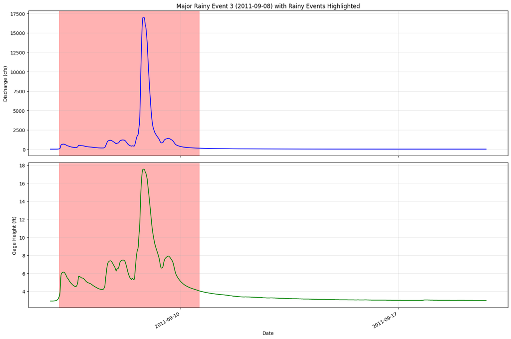

```python
def plot_discharge_with_events(data, events, start_date, end_date, title):
    """
    Plot discharge data with rainy events highlighted.

    Parameters:
    - data: DataFrame with discharge data
    - events: List of rainy events (start, end) tuples
    - start_date, end_date: Period to plot
    - title: Plot title
    """
    # Filter data to the specified period
    period_data = data.loc[start_date:end_date]

    # Create a figure with two subplots (for discharge and gage height)
    fig, (ax1, ax2) = plt.subplots(2, 1, figsize=(15, 10), sharex=True)

    # Plot water discharge
    ax1.plot(period_data.index, period_data['water_discharge'], color='blue', linewidth=1.5)
    ax1.set_ylabel('Discharge (cfs)')
    ax1.set_title(f'{title} with Rainy Events Highlighted')
    ax1.grid(True, alpha=0.3)

    # Plot gage height
    ax2.plot(period_data.index, period_data['gage_height'], color='green', linewidth=1.5)
    ax2.set_ylabel('Gage Height (ft)')
    ax2.set_xlabel('Date')
    ax2.grid(True, alpha=0.3)

    # Highlight rainy events that overlap the plotted period
    for event_start, event_end in events:
        if event_end >= start_date and event_start <= end_date:
            highlight_start = max(event_start, start_date)
            highlight_end = min(event_end, end_date)
            ax1.axvspan(highlight_start, highlight_end, color='red', alpha=0.3)
            ax2.axvspan(highlight_start, highlight_end, color='red', alpha=0.3)

    # Format the x-axis to show dates nicely
    ax2.xaxis.set_major_formatter(mdates.DateFormatter('%Y-%m-%d'))
    ax2.xaxis.set_major_locator(mdates.DayLocator(interval=7))
    fig.autofmt_xdate()

    plt.tight_layout()
    plt.show()

# Plot an approximate one-year period to visualize seasonal patterns
year_start = df.index.min() + pd.DateOffset(months=6)  # Start 6 months in to avoid edge effects
year_end = year_start + pd.DateOffset(years=1)
plot_discharge_with_events(df, rainy_events, year_start, year_end,
                           f"One Year of Discharge Data ({year_start.strftime('%Y-%m-%d')} to {year_end.strftime('%Y-%m-%d')})")

# Zoom in on some major events to see details
peak_discharges = df['water_discharge'].nlargest(5)
print("\nTop 5 peak discharge events:")
for date, discharge in peak_discharges.items():
    print(f"{date.strftime('%Y-%m-%d %H:%M')}: {discharge:.2f} cfs")

# Plot a 2-week window around the top 3 discharge events
top_events = list(peak_discharges.items())[:3]
for i, (date, discharge) in enumerate(top_events):
    event_start = date - pd.Timedelta(days=3)
    event_end = date + pd.Timedelta(days=11)
    plot_discharge_with_events(df, rainy_events, event_start, event_end,
                               f"Major Rainy Event {i+1} ({date.strftime('%Y-%m-%d')})")
```

## Step 4: Statistical Summary of Rainy Events

After detecting the rainy events, I calculated statistics to summarize the findings:

- **Event Duration:** The average, minimum, and maximum duration (in hours) of the detected rainy events.
- **Events per Year:** The average number of rainy events per year.
- **Time in Rainy Events:** The percentage of the total dataset time during which rainy events occur.

```python
# Calculate durations of each rainy event in hours
event_durations = [(end - start).total_seconds() / 3600 for start, end in rainy_events]
print(f"\nEvent Statistics:")
print(f"Average event duration: {np.mean(event_durations):.1f} hours")
print(f"Minimum event duration: {np.min(event_durations):.1f} hours")
print(f"Maximum event duration: {np.max(event_durations):.1f} hours")

# Calculate the average number of events per year
years_spanned = (df.index.max() - df.index.min()).days / 365.25
events_per_year = len(rainy_events) / years_spanned
print(f"Average number of rainy events per year: {events_per_year:.1f}")

# Calculate the percentage of time with rainy events
total_hours_in_events = sum(event_durations)
total_hours_in_dataset = (df.index.max() - df.index.min()).total_seconds() / 3600
percent_time_in_events = (total_hours_in_events / total_hours_in_dataset) * 100
print(f"Percentage of time in rainy events: {percent_time_in_events:.1f}%")
```

```
Event Statistics:
Average event duration: 48.1 hours
Minimum event duration: 24.0 hours
Maximum event duration: 235.5 hours
Average number of rainy events per year: 29.7
Percentage of time in rainy events: 16.3%
```

## Conclusion: Detection of Rainy Events in the Difficult Run Watershed

In this exercise, I developed a simple algorithm to detect rainy events in the discharge data of the Difficult Run watershed. Key points include:

- **Methodology:**
  - I calculated the rate of change in discharge measurements.
  - A threshold was set at the 98th percentile of the smoothed change values to isolate significant increases.
  - Events were grouped together if they occurred within a 48-hour gap, ensuring that closely spaced spikes were merged into a single rainy event.
- **Results:**
  - The one-year plot (**Image 1**) shows multiple rainy events throughout the year, with the discharge rapidly responding to precipitation.
  - A major event on September 8, 2011, is highlighted in detail by the subsequent zoomed-in plots (**Images 2–4**). These images depict an extreme discharge peak (around 17,000 cfs) and a corresponding gage height increase (approximately 17 ft), typical of flash flood behavior with a sharp rising limb and a more gradual recession.
- **Significance:**
  - This approach effectively captures the rapid response of small streams during rain events.
  - The temporal pattern and magnitude of these events provide valuable information for flood risk assessment and water resource management.

Overall, the algorithm successfully identifies periods of significant hydrologic response, offering important insights into the watershed's behavior during storm events.

# Exercise 5: Analysis of Maximum Discharge Values in the Difficult Run Watershed

In this exercise, I analyze the distribution of annual maximum water discharge values extracted from the Difficult Run dataset. My objectives are to:

- Extract annual maximum discharge values from a 10-year dataset.
- Plot the frequency distribution (histogram) of these maximum values.
- Fit an appropriate theoretical distribution to the data—in this case, the Gumbel distribution (Extreme Value Type I).
- Support the choice of probabilistic model using both visual fit (histogram and empirical cumulative distribution function, ECDF) and quantitative measures (AIC).

This analysis is fundamental for understanding the behavior of extreme discharge events, which is critical for flood risk assessment and hydrological design.

## Step 1: Load Data and Extract Annual Maximum Discharge Values

I start by loading the 10-year dataset and converting the `datetime` column to datetime objects. Then, I set it as the DataFrame index for easier time-series manipulation and resample the data to extract the annual maximum discharge values.

```python
import pandas as pd
import numpy as np
import matplotlib.pyplot as plt
import scipy.stats as stats

# Load the 10-year dataset
df = pd.read_csv('difficult_run_10yr_data.csv')
df['datetime'] = pd.to_datetime(df['datetime'])
df.set_index('datetime', inplace=True)

# Extract annual maximum discharge values and sort them
annual_max = df.resample('YE')['water_discharge'].max().sort_values()
```

## Step 2: Plot Histogram and Fit the Gumbel Distribution

I then plot a histogram of the annual maximum discharge values. To model the extreme events,I fit a Gumbel distribution, a common choice in extreme value analysis—to the data. The left subplot shows the histogram with the fitted Gumbel probability density function (PDF) along with its AIC value. The right subplot displays the empirical cumulative distribution function (ECDF) and the theoretical Gumbel cumulative distribution function (CDF) for further comparison.

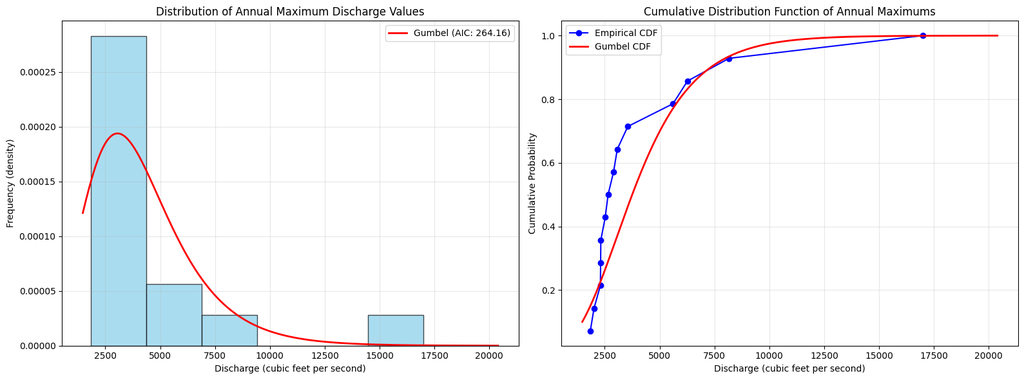

```python
# Create a figure with two subplots for better visualization
fig, (ax1, ax2) = plt.subplots(1, 2, figsize=(16, 6))

# Left plot: Histogram of annual maximum values with fitted Gumbel PDF
ax1.hist(annual_max.values, bins=6, alpha=0.7, color='skyblue',
         edgecolor='black', density=True)
ax1.set_title('Distribution of Annual Maximum Discharge Values')
ax1.set_xlabel('Discharge (cubic feet per second)')
ax1.set_ylabel('Frequency (density)')
ax1.grid(True, alpha=0.3)

# Fit Gumbel distribution to the annual maximum values
gumbel_params = stats.gumbel_r.fit(annual_max.values)
gumbel_aic = -2 * np.sum(stats.gumbel_r.logpdf(annual_max.values, *gumbel_params)) + 2 * len(gumbel_params)

# Plot the fitted Gumbel distribution on the histogram
x = np.linspace(min(annual_max.values) * 0.8, max(annual_max.values) * 1.2, 1000)
ax1.plot(x, stats.gumbel_r.pdf(x, *gumbel_params),
         'r-', linewidth=2, label=f'Gumbel (AIC: {gumbel_aic:.2f})')
ax1.legend()

# Right plot: Empirical CDF vs. Theoretical Gumbel CDF
sorted_data = np.sort(annual_max.values)
ecdf = np.arange(1, len(sorted_data) + 1) / len(sorted_data)

ax2.plot(sorted_data, ecdf, 'bo-', label='Empirical CDF')
ax2.plot(x, stats.gumbel_r.cdf(x, *gumbel_params), 'r-', linewidth=2,
         label='Gumbel CDF')
ax2.set_title('Cumulative Distribution Function of Annual Maximums')
ax2.set_xlabel('Discharge (cubic feet per second)')
ax2.set_ylabel('Cumulative Probability')
ax2.grid(True, alpha=0.3)
ax2.legend()

plt.tight_layout()
plt.show()
```

**Figure 13.** Distribution analysis of annual maximum discharge values showing (left) histogram with fitted Gumbel distribution (AIC: 264.16) overlaid in red, and (right) comparison of empirical cumulative distribution function (blue dots) versus theoretical Gumbel CDF (red line), demonstrating that the Gumbel distribution provides a good fit for modeling extreme discharge events in flood frequency analysis.

## Step 3: Evaluate the Fitted Model

I compare the fit of the Gumbel distribution by considering its AIC value. A lower AIC indicates a better balance of model complexity and goodness-of-fit. I then print the parameters of the fitted Gumbel distribution to understand its characteristics.

```python
# Print the parameters of the Gumbel distribution and supporting information
print("Parameters of the Gumbel distribution:")
print(f"Location parameter (μ): {gumbel_params[0]:.4f}")
print(f"Scale parameter (β): {gumbel_params[1]:.4f}")
print(f"\nAIC Value: {gumbel_aic:.2f}")
```

```
Parameters of the Gumbel distribution:
Location parameter (μ): 3055.1386
Scale parameter (β): 1896.7075

AIC Value: 264.16
```

## Conclusion: Analysis of Maximum Discharge Values

Overall, the Gumbel distribution appropriately characterizes the maximum discharge values in the Difficult Run watershed, providing a robust basis for estimating the probability of extreme events and supporting flood risk assessments.

# Exercise 6: Analysis of Sunny Intervals Between Rainy Events

In this exercise, I analyze the time intervals between consecutive rainy events (i.e., the “sunny intervals”) using the Difficult Run 10-year discharge dataset. The objectives are to:

- Detect rainy events in the discharge data using a discharge rate-of-change algorithm.
- Calculate the duration (in days) of sunny intervals between these events.
- Plot the distribution of sunny intervals using a histogram.
- Use a Kernel Density Estimation (KDE) to model the distribution of interval durations and support the choice of a non-parametric model.

This analysis provides insights into the typical dry periods between rain events, which has implications for water resource management and hydrological modeling.

## Step 1: Load and Preprocess the Data

I start by loading the 10-year dataset, converting the `datetime` column to datetime objects, and setting it as the DataFrame index (after sorting) to facilitate time series handling.

```python
import pandas as pd
import numpy as np
import matplotlib.pyplot as plt
import scipy.stats as stats
from datetime import timedelta
from scipy.stats import gaussian_kde
import matplotlib.dates as mdates

# Load the 10-year dataset
df = pd.read_csv('difficult_run_10yr_data.csv')
df['datetime'] = pd.to_datetime(df['datetime'])
df.set_index('datetime', inplace=True)
df = df.sort_index()
```

## Step 2: Detect Rainy Events

To identify rainy events, I use a discharge rate-of-change algorithm. The steps are:

1. Calculate the first derivative (rate of change) of the discharge.
2. Smooth the values with a rolling window to reduce noise.
3. Determine a threshold (here the 98th percentile) for significant increases.
4. Group consecutive time points exceeding the threshold into single events, ensuring a minimum gap of 48 hours between separate events.

The function below implements this logic.

```python
def detect_rainy_events(discharge_series, threshold_percentile=95, window_size=24, min_event_gap=48):
    """
    Detect rainy events based on discharge rate of change.

    Parameters:
    - discharge_series: Series of discharge values
    - threshold_percentile: Percentile to use as threshold for significant discharge increases
    - window_size: Window (in hours) used to decide the event duration after a significant increase
    - min_event_gap: Minimum gap (in hours) between separate events

    Returns:
    - List of tuples with the start and end times of detected rainy events.
    """
    # Calculate rate of change (first derivative)
    discharge_change = discharge_series.diff()

    # Smooth using a rolling window to reduce noise
    discharge_change_smooth = discharge_change.rolling(window=6, center=True).mean()

    # Determine threshold using the specified percentile
    threshold = np.percentile(discharge_change_smooth.dropna(), threshold_percentile)
    print(f"Threshold for detecting significant discharge increases: {threshold:.2f} cfs/hour")

    # Detect where the discharge increase exceeds the threshold
    significant_increase = discharge_change_smooth > threshold

    # Group consecutive detections into events
    events = []
    in_event = False
    event_start = None
    last_increase = None

    for time, is_increase in significant_increase.items():
        if is_increase and not in_event:
            # Start a new event
            event_start = time
            in_event = True
            last_increase = time
        elif is_increase and in_event:
            # Continue current event
            last_increase = time
        elif not is_increase and in_event:
            # Check if the gap since the last increase exceeds window_size
            hours_since_increase = (time - last_increase).total_seconds() / 3600
            if hours_since_increase > window_size:
                event_end = last_increase + pd.Timedelta(hours=window_size)
                events.append((event_start, event_end))
                in_event = False

    # If still in an event, close it
    if in_event:
        event_end = last_increase + pd.Timedelta(hours=window_size)
        events.append((event_start, event_end))

    # Merge events that occur too close together (within min_event_gap hours)
    if events:
        merged_events = [events[0]]
        for event_start, event_end in events[1:]:
            prev_start, prev_end = merged_events[-1]
            hours_between = (event_start - prev_end).total_seconds() / 3600
            if hours_between < min_event_gap:
                merged_events[-1] = (prev_start, event_end)
            else:
                merged_events.append((event_start, event_end))
        return merged_events
    else:
        return []

# Detect rainy events using a 98th percentile threshold
rainy_events = detect_rainy_events(df['water_discharge'], threshold_percentile=98, window_size=24, min_event_gap=48)
print(f"Detected {len(rainy_events)} rainy events")
```

```
Threshold for detecting significant discharge increases: 7.17 cfs/hour
Detected 415 rainy events
```

## Step 3: Calculate Sunny Intervals

Once rainy events are detected, I compute the durations of the "sunny intervals"—that is, the time gaps between consecutive rainy events. These intervals are expressed in days.

```python
# Calculate sunny intervals between consecutive rainy events (in days)
sunny_intervals = []
for i in range(len(rainy_events) - 1):
    current_event_end = rainy_events[i][1]
    next_event_start = rainy_events[i + 1][0]
    interval_days = (next_event_start - current_event_end).total_seconds() / (24 * 3600)
    sunny_intervals.append(interval_days)

# Print basic statistics of sunny intervals
print(f"Detected {len(rainy_events)} rainy events")
print(f"Number of sunny intervals: {len(sunny_intervals)}")
print(f"Average sunny interval: {np.mean(sunny_intervals):.2f} days")
print(f"Minimum sunny interval: {np.min(sunny_intervals):.2f} days")
print(f"Maximum sunny interval: {np.max(sunny_intervals):.2f} days")
```

```
Detected 415 rainy events
Number of sunny intervals: 414
Average sunny interval: 10.29 days
Minimum sunny interval: 2.02 days
Maximum sunny interval: 61.59 days
```

## Step 4: Plot the Distribution of Sunny Intervals

I now plot a histogram of the sunny intervals (in days) between rainy events. Because the data display a complex, right-skewed distribution that standard parametric models may not capture well, I apply a non-parametric Kernel Density Estimation (KDE) to model the distribution. The KDE provides a smooth curve that adapts to the data without imposing a specific parametric form.

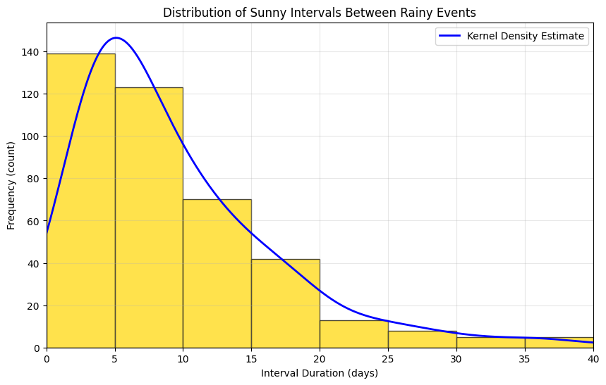

```python
# Create a histogram of sunny intervals
plt.figure(figsize=(10, 6))
counts, bins, _ = plt.hist(sunny_intervals, bins=8, alpha=0.7, color='gold', edgecolor='black', range=(0, 40))
plt.title('Distribution of Sunny Intervals Between Rainy Events')
plt.xlabel('Interval Duration (days)')
plt.ylabel('Frequency (count)')
plt.grid(True, alpha=0.3)

# Apply Kernel Density Estimation for a smooth distribution estimate
kde = gaussian_kde(sunny_intervals, bw_method=0.3)  # Adjust bandwidth for smoothness
x_kde = np.linspace(0, 40, 1000)
y_kde = kde(x_kde) * len(sunny_intervals) * (bins[1] - bins[0])
plt.plot(x_kde, y_kde, 'b-', linewidth=2, label='Kernel Density Estimate')
plt.legend()
plt.xlim(0, 40)
plt.show()
```

## Conclusion: Analysis of Sunny Intervals Between Rainy Events

In this exercise, I analyzed the distribution of time intervals between consecutive rainy events in the Difficult Run watershed. Key findings include:

- **Methodology:** I calculated sunny intervals by computing the time gaps (in days) between the end of one rainy event and the start of the next. With 414 intervals computed from 415 rainy events, the basic statistics show:
  - Average interval duration: 10.29 days
  - Minimum interval duration: 2.02 days
  - Maximum interval duration: 61.59 days
- **Distribution Characteristics:** The histogram of sunny intervals displays a right-skewed distribution, with most intervals lasting between 2–10 days; however, longer intervals (beyond 20 days) do occur.
- **Model Choice:** Given the complex, non-parametric nature of these intervals, I used a Kernel Density Estimation (KDE) rather than forcing a standard parametric distribution. The KDE approach:
  1. Adapts naturally to the actual data without imposing theoretical constraints.
  2. Clearly represents the observed tendency for most intervals to be short (around 5–6 days), with a gradual decline in frequency for longer dry periods.
- **Hydrological Implications:** This distribution reflects common weather patterns in the mid-Atlantic region, with frequent short dry spells interspersed with occasional longer intervals. These results can be used in water resource planning and in assessing ecological impacts on the stream ecosystem.

Overall, the KDE successfully characterizes the distribution of sunny intervals, providing valuable insights into the temporal patterns of rainfall and dry periods in the Difficult Run watershed.